# 2020 Vision - New York Public High School Graduation Rate Trends

Amber Wang CMSC320 Spring 2021

## Motivation: Who Cares About Graduation Rates?

Well, as a student, me. Probably a lot of parents. And you should, too! As a society, we've agreed that education is important - graduating high school is that first step towards either higher education or starting to make one's way in the world. It's also traditionally been a huge barrier to lower income/minority groups, though over many years we've started pushing those graduation rates upwards throughout the country. Citizens who graduate with high school diplomas are more likely to vote, be employed, have higher salaries, and even live longer.

Studying graduation rates and what factors affect those rates can change the way that we provide education, hopefully fostering a better experience for students who may be struggling. Graduation rates in high schools can tell us about which demographic groups are still educationally disadvantaged and can inform decisions about where to put funding.

Here's our first little bit of code - let's import the libraries we're going to want to use for our data cleaning, exploration, and analysis down the line. We don't want to reinvent the wheel and perform complicated analyses ourselves, so we use tools curated by people much more statistics-saavy than us who have laid the groundwork! :)

```python
import pandas as pd # store and manipulate the data
import numpy as np # basic math/array manipulation tools for Python
import matplotlib.pyplot as plt # plotting
import seaborn as sns # more, different plotting
import statsmodels.api as sm # linear regression
from sklearn.metrics import r2_score # calculate r2 of linear regression later
```

## The Dataset

Our data comes from the [New York State Education Department](https://data.nysed.gov/downloads.php)'s graduation rate database for the 2019-2020 academic school year. The data file, compiled and released in early 2021, includes information about graduation rates pre-grouped by county, district, and also distinguished by demographic features like gender and race. Usign this data set, we can pull some analysis of what factors influence high school graduation in New York's 4,772 public and charter high schools.

Let's download the CSV file provided by NYSED and load it into a pandas dataframe so that we can work with the data later on! Pandas is an extremely common and extremely useful library that contains many functions perfect for working with data. For more information about pandas, read their [guide to getting started](https://pandas.pydata.org/pandas-docs/stable/getting_started/index.html).

```python
# Read data into a pandas dataframe using read_csv
data = pd.read_csv("GRAD_RATE_AND_OUTCOMES_2020.csv", dtype={'entity_inactive_date': str, 'lea_name':str})
data.head(10) # easy as that!
```

|  | report_school_year | aggregation_index | aggregation_type | aggregation_code | aggregation_name | entity_inactive_date | lea_beds | lea_name | nrc_code | nrc_desc | ... | reg_adv_cnt | reg_adv_pct | non_diploma_credential_cnt | non_diploma_credential_pct | still_enr_cnt | still_enr_pct | ged_cnt | ged_pct | dropout_cnt | dropout_pct |
| --- | --- | --- | --- | --- | --- | --- | --- | --- | --- | --- | --- | --- | --- | --- | --- | --- | --- | --- | --- | --- | --- |
| 0 | 2019-20 | 0 | Statewide | 0 | All Districts and Charters | NaN | NaN | NaN | NaN | NaN | ... | 70787 | 34% | 2577 | 1% | 4911 | 2% | 1579 | 1% | 18517 | 9% |
| 1 | 2019-20 | 0 | Statewide | 0 | All Districts and Charters | NaN | NaN | NaN | NaN | NaN | ... | 38431 | 38% | 863 | 1% | 1757 | 2% | 600 | 1% | 7192 | 7% |
| 2 | 2019-20 | 0 | Statewide | 0 | All Districts and Charters | NaN | NaN | NaN | NaN | NaN | ... | 32356 | 30% | 1714 | 2% | 3154 | 3% | 979 | 1% | 11325 | 11% |
| 3 | 2019-20 | 0 | Statewide | 0 | All Districts and Charters | NaN | NaN | NaN | NaN | NaN | ... | 258 | 19% | 21 | 2% | 55 | 4% | 17 | 1% | 215 | 16% |
| 4 | 2019-20 | 0 | Statewide | 0 | All Districts and Charters | NaN | NaN | NaN | NaN | NaN | ... | 4453 | 12% | 596 | 2% | 1419 | 4% | 393 | 1% | 4658 | 13% |
| 5 | 2019-20 | 0 | Statewide | 0 | All Districts and Charters | NaN | NaN | NaN | NaN | NaN | ... | 8084 | 16% | 591 | 1% | 1557 | 3% | 638 | 1% | 7754 | 15% |
| 6 | 2019-20 | 0 | Statewide | 0 | All Districts and Charters | NaN | NaN | NaN | NaN | NaN | ... | 10926 | 55% | 139 | 1% | 270 | 1% | 76 | 0% | 966 | 5% |
| 7 | 2019-20 | 0 | Statewide | 0 | All Districts and Charters | NaN | NaN | NaN | NaN | NaN | ... | 46079 | 47% | 1199 | 1% | 1531 | 2% | 436 | 0% | 4637 | 5% |
| 8 | 2019-20 | 0 | Statewide | 0 | All Districts and Charters | NaN | NaN | NaN | NaN | NaN | ... | 987 | 31% | 31 | 1% | 79 | 3% | 19 | 1% | 287 | 9% |
| 9 | 2019-20 | 0 | Statewide | 0 | All Districts and Charters | NaN | NaN | NaN | NaN | NaN | ... | 69606 | 39% | 75 | 0% | 2096 | 1% | 1153 | 1% | 13184 | 7% |

10 rows × 37 columns

## Data Cleaning

```python
storesafe = data
```

Wowza, 227450 rows, 37 columns, and a lot of missing values - that's a big dataset! Let's start paring it down a bit. Luckily, this dataset is already quite well organized, and there are many ways to extract smaller subsets.

We do this by selecting the cohorts we want to study and by dropping all columns we won't be interested in, like year (it's all from 2019-2020), repeat information (group codes that are the same as group names), and some other extra information (like distinguishing between types of diplomas). We'll just save aggregation_index, some identifying columns, demographic indicators, and graduation rates.

We also want to mark rows that don't have relevant information. The dataset suppresses information for subgroups with small numbers (like 4 or 5) to protect student anonymity. Currently, they're marked as "-"; let's change it to NaN and drop the rows that don't have graduation data. Note that this missing data is missing because of a known factor - enrollment count for a particular subgroup. That makes it MAR data. Handling that kind of missing data is a bit outside the scope of this tutorial, but [imputation](https://scikit-learn.org/stable/modules/impute.html) is a potential solution. For now, we'll just drop the observations for the data we don't have ([complete case analysis](https://www.sciencedirect.com/topics/mathematics/complete-case-analysis)), but we should keep in mind that extremely small groups are potentially not represented in district and school-level data.

```python
data = storesafe
# Keep data for students in four-year cohort (started high school in 2016)
data = data[data['membership_code'] == 9]

# Remove all columns but the ones that we'll use for our exploration
to_keep = ['aggregation_index','aggregation_code','county_name', 'nrc_code', 'subgroup_code','subgroup_name', \
           'enroll_cnt','grad_cnt','grad_pct', 'dropout_cnt', 'dropout_pct']
data = data[to_keep]

# Replace '-' suppressed values with NaN for consistency
data = data.replace('-', np.NaN)

# Now drop rows where we don't have grad data (complete case analysis, aka. listwise deletion)
data = data[data['grad_cnt'].notna()]

#Change grad_cnt, grad_pct, dropout_cnt, and dropout_pct into numerical values so we can do computations
data['grad_cnt'] = pd.to_numeric(data['grad_cnt'])
data['grad_pct'] = data['grad_pct'].apply(lambda x: x.strip('%')) # remove % sign
data['grad_pct'] = pd.to_numeric(data['grad_pct'])
data['grad_pct'] = data['grad_pct']/100 # divide by 100 to get pct
data['dropout_cnt'] = pd.to_numeric(data['dropout_cnt'])
data['dropout_pct'] = data['dropout_pct'].apply(lambda x: x.strip('%')) # remove % sign
data['dropout_pct'] = pd.to_numeric(data['dropout_pct'])
data['dropout_pct'] = data['dropout_pct']/100 # divide by 100 to get pct

data = data.reset_index(drop=True) # reset dataframe indices

data.head(10)
```

|  | aggregation_index | aggregation_code | county_name | nrc_code | subgroup_code | subgroup_name | enroll_cnt | grad_cnt | grad_pct | dropout_cnt | dropout_pct |
| --- | --- | --- | --- | --- | --- | --- | --- | --- | --- | --- | --- |
| 0 | 0 | 0 | NaN | NaN | 1 | All Students | 208449 | 174271 | 0.84 | 10580 | 0.05 |
| 1 | 0 | 0 | NaN | NaN | 2 | Female | 101316 | 88795 | 0.88 | 3909 | 0.04 |
| 2 | 0 | 0 | NaN | NaN | 3 | Male | 107133 | 85476 | 0.80 | 6671 | 0.06 |
| 3 | 0 | 0 | NaN | NaN | 4 | American Indian/Alaska Native | 1404 | 1060 | 0.75 | 144 | 0.10 |
| 4 | 0 | 0 | NaN | NaN | 5 | Black | 36351 | 27714 | 0.76 | 2198 | 0.06 |
| 5 | 0 | 0 | NaN | NaN | 6 | Hispanic | 53990 | 40391 | 0.75 | 4445 | 0.08 |
| 6 | 0 | 0 | NaN | NaN | 7 | Asian/Pacific Islander | 20137 | 18077 | 0.90 | 602 | 0.03 |
| 7 | 0 | 0 | NaN | NaN | 8 | White | 92962 | 84052 | 0.90 | 2994 | 0.03 |
| 8 | 0 | 0 | NaN | NaN | 9 | Multiracial | 3605 | 2977 | 0.83 | 197 | 0.05 |
| 9 | 0 | 0 | NaN | NaN | 10 | General Education Students | 173222 | 152915 | 0.88 | 7691 | 0.04 |

We also don't need all of the rows because most of them are actually repeated information, just organized in different ways. According to the README for the dataset, the "aggregation_index" column tells us what category grouping the nice people who put together the data have used. Each one is a different lens of looking at the data. They've split it as follows:

0 - Statewide

1 - Needs/Resource Capacity (measure of district's ability to meet the needs of its students - 7 subdesignations)

2 - County

3 - District

4 - School

The first grouping, statewide, is useful to have just so we know big picture statistics and can find demographic trends for the entire state of New York. We can extract that dataset and drop unnecessary columns.

The next grouping, needs/resource capacity, is one that I'm very interested in, as it categorizes students within the context of resources its districts can provide. In this way we can shed light on demographic comparisons within relative socioeconomic groupings.

The next aggregation grouping that I'm interested in is county. County is a good grouping for this data because each county's subgroups won't be so small that we have a lot of that missing, suppressed data mentioned before.

Finally, we'll also extract district data. Districts have the benefit of not being as small as the school designation but still having enough data that we can work with later when we make do our regression model. Also, districts have N/RC codes that we can use to classify, too!

Let's extract these smaller datasets so that we can do more targeted exploration late! For each dataset, we'll drop columns that are irrelevant to us.

```python
# Extract entire-statewide data
grad_state = data[data['aggregation_index'] == 0]

# Drop columns we no longer need (mostly for aggregation)
grad_state = grad_state.drop(labels=['aggregation_index', 'aggregation_code', 'county_name', 'nrc_code'], \
                             axis = 1)
grad_state = grad_state.reset_index(drop=True) # reset dataframe indices

grad_state.head(5)
```

|  | subgroup_code | subgroup_name | enroll_cnt | grad_cnt | grad_pct | dropout_cnt | dropout_pct |
| --- | --- | --- | --- | --- | --- | --- | --- |
| 0 | 1 | All Students | 208449 | 174271 | 0.84 | 10580 | 0.05 |
| 1 | 2 | Female | 101316 | 88795 | 0.88 | 3909 | 0.04 |
| 2 | 3 | Male | 107133 | 85476 | 0.80 | 6671 | 0.06 |
| 3 | 4 | American Indian/Alaska Native | 1404 | 1060 | 0.75 | 144 | 0.10 |
| 4 | 5 | Black | 36351 | 27714 | 0.76 | 2198 | 0.06 |

We've created a dataset with the statewide graduate and droupout data for different demographics! This dataframe is quite small, with only 24 rows (one for each subgroup).

```python
# Extract Need to Resource Capacity(NRC)-subdivided data
grad_nrc = data[data['aggregation_index'] == 1]


# Drop columns we no longer need (mostly for aggregation)
grad_nrc = grad_nrc.drop(labels=['aggregation_index', 'county_name', 'nrc_code'], axis = 1)
grad_nrc.rename(columns={'aggregation_code':'category'}, inplace=True) #rename column for clarity
grad_nrc = grad_nrc.reset_index(drop=True) # reset dataframe indices

grad_nrc.head(5)
```

|  | category | subgroup_code | subgroup_name | enroll_cnt | grad_cnt | grad_pct | dropout_cnt | dropout_pct |
| --- | --- | --- | --- | --- | --- | --- | --- | --- |
| 0 | 1 | 1 | All Students | 74523 | 57322 | 0.77 | 4368 | 0.06 |
| 1 | 1 | 2 | Female | 36299 | 30049 | 0.83 | 1506 | 0.04 |
| 2 | 1 | 3 | Male | 38224 | 27273 | 0.71 | 2862 | 0.07 |
| 3 | 1 | 4 | American Indian/Alaska Native | 698 | 506 | 0.72 | 73 | 0.10 |
| 4 | 1 | 5 | Black | 19256 | 14202 | 0.74 | 1128 | 0.06 |

Now we have a dataset split by need to resource capacity categories. Encodings, found in the category column, are as follows:

1: New York City (High N/RC - above 70th percentile)

2: Large City High Districts - Buffalo, Rochester, Syracuse, Yonkers (High N/RC)

3: Urban-Suburban High Districts (High N/RC)

4: Rural High Districts (High N/RC)

5: Average Districts (Medium N/RC - 20-70th percentile)

6: Low Districts (Low N/RC - below 20th percentile)

7: Charter Schools

where, generally, a lower N/RC ratio designation indicates a district's greater "ability to meet the needs of its students with local resources", per the README. More specifically, it's the ratio between estimated poverty level and combined wealth ratio. More information about the designations can be found at [NYSED's website](http://www.p12.nysed.gov/irs/accountability/2011-12/NeedResourceCapacityIndex.pdf).

```python
# Extract county-subdivided data
grad_county = data[data['aggregation_index'] == 2]

# Drop columns we no longer need (mostly for aggregation)
grad_county = grad_county.drop(labels=['aggregation_index', 'aggregation_code', 'nrc_code'], axis = 1)
grad_county = grad_county.reset_index(drop=True) # reset dataframe indices

grad_county.head(5)
```

|  | county_name | subgroup_code | subgroup_name | enroll_cnt | grad_cnt | grad_pct | dropout_cnt | dropout_pct |
| --- | --- | --- | --- | --- | --- | --- | --- | --- |
| 0 | ALBANY | 1 | All Students | 3117 | 2712 | 0.87 | 177 | 0.06 |
| 1 | ALBANY | 2 | Female | 1588 | 1426 | 0.90 | 82 | 0.05 |
| 2 | ALBANY | 3 | Male | 1529 | 1286 | 0.84 | 95 | 0.06 |
| 3 | ALBANY | 4 | American Indian/Alaska Native | 8 | 5 | 0.63 | 0 | 0.00 |
| 4 | ALBANY | 5 | Black | 660 | 502 | 0.76 | 58 | 0.09 |

Now we also have a simple dataset of counties and 4-year student subgroups within counties that we can work with when we want to compare counties (all 62 of them) against each other!

```python
# Extract district data

grad_district = data[data['aggregation_index'] == 3]

# Drop columns we no longer need (mostly for aggregation)
grad_district = grad_district.drop(labels=['aggregation_index', 'aggregation_code'], axis = 1)
grad_district = grad_district.reset_index(drop=True) # reset dataframe indices

grad_district.head(5)
```

|  | county_name | nrc_code | subgroup_code | subgroup_name | enroll_cnt | grad_cnt | grad_pct | dropout_cnt | dropout_pct |
| --- | --- | --- | --- | --- | --- | --- | --- | --- | --- |
| 0 | ALBANY | 3.0 | 1 | All Students | 722 | 508 | 0.70 | 88 | 0.12 |
| 1 | ALBANY | 3.0 | 2 | Female | 368 | 278 | 0.76 | 47 | 0.13 |
| 2 | ALBANY | 3.0 | 3 | Male | 354 | 230 | 0.65 | 41 | 0.12 |
| 3 | ALBANY | 3.0 | 5 | Black | 383 | 252 | 0.66 | 45 | 0.12 |
| 4 | ALBANY | 3.0 | 6 | Hispanic | 108 | 73 | 0.68 | 20 | 0.19 |

With our final district dataset in place, we can now move onto the fun part: data exploration.

## Data Exploration

It's time to find out what patterns we might spot in the data and what we can explore! Our goal is to see what subgroups impact graduation rate, so let's compare different demographics. We can extract relevant portions of the subgroup data and compare them against each other.

We'll start with one of the basics: sex. NYSED splits the counts between female and male. There are a number of ways we can choose to represent this statistics in graphical form, but I choose a bar graph because we're trying to compare single, representative (average) values from two categories. We'll start with aggregate data of all students, ignoring county for now. Matplotlib can help us create a quick, simple graph to compare male and female graduation rates from the cohort, and then droupout rates as well.

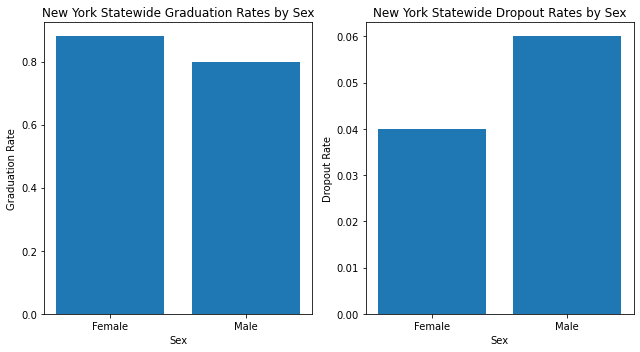

```python
# Plot graduation rates for male vs female

plt.figure(figsize=(9,5)) # some plot setup - size, subplot puts plots next to each other
plt.subplot(1, 2, 1)
x = ['Female', 'Male'] # categories are female and male
y = [grad_state['grad_pct'][1], grad_state['grad_pct'][2]] # y values from state data
plt.bar(x, y) # plot

# Always label your graphs!
plt.title("New York Statewide Graduation Rates by Sex")
plt.xlabel("Sex")
plt.ylabel("Graduation Rate")

# Plot dropout rates for male vs female
plt.subplot(1, 2, 2) # next graph to plot on
y = [grad_state['dropout_pct'][1], grad_state['dropout_pct'][2]]
plt.bar(x, y)

# Label!
plt.title("New York Statewide Dropout Rates by Sex")
plt.xlabel("Sex")
plt.ylabel("Dropout Rate")
plt.tight_layout()
```

Pretty boring result! Well, we can see that in 2020, females had a higher graduation percentage than males, with an overall difference of 8%. Dropout rates in females are also lower by 2%, so it doesn't completely explain the gap - males might just be taking longer to graduate.

Let's try to explore how that breaks down between the different counties by creating a grouped bar graph that will show us the female/male breakdown for each county following [Matplotlib's grouped bar chart example](https://matplotlib.org/stable/gallery/lines_bars_and_markers/barchart.html). We could also achieve the same graph using Seaborn's [bar graph functionality](http://seaborn.pydata.org/generated/seaborn.barplot.html#seaborn.barplot).

Here's a bit of difficulty: New York has 62 counties. These won't fit nicely into a single bar graph, but let's plot a number of the first ones that appear in the dataset (alphabetically) to see how they might be able to compare (if we had had a normal, smaller amount of them). We'll designate a limit so we can easily change how big of a slice we want.

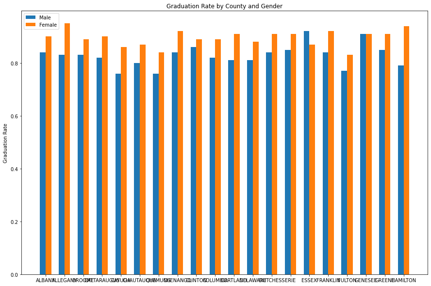

```python
counties = grad_county.county_name.unique() # our labels will be the county names!
male = []
female = []

limit = 20 # control how many counties we see

# Create list of male/female graduation statistics by going through each county and collecting the graduation rate
for county in counties:
    male.append(list(grad_county[(grad_county['county_name'] == county) & \
                                 (grad_county['subgroup_name'] == 'Male')]['grad_pct'])[0])
    female.append(list(grad_county[(grad_county['county_name'] == county) & \
                                   (grad_county['subgroup_name'] == 'Female')]['grad_pct'])[0])

# Align the two side-by-side bar graphs
x = np.arange(len(counties[:limit]))
width = 0.3
fig, ax = plt.subplots()
fig = plt.gcf()
fig.set_size_inches(15, 10) # make the plot bigger!
rects1 = ax.bar(x - width/2, male[:limit], width, label='Male')
rects2 = ax.bar(x + width/2, female[:limit], width, label='Female')

# Labeling!
ax.set_ylabel('Graduation Rate')
ax.set_title('Graduation Rate by County and Gender')
ax.set_xticks(x)
ax.set_xticklabels(counties[:limit])
ax.legend()

plt.show()
```

Oh, my. Clearly even graphing a third of the counties this way is decently overwhelming and hard to look at. Even from this, we can see some clear variation between counties, though. Let's try something else: differences! If we're only looking for gender differences, we can pare down some of the information by subtracting male from female graduation rates and graphing those, instead.

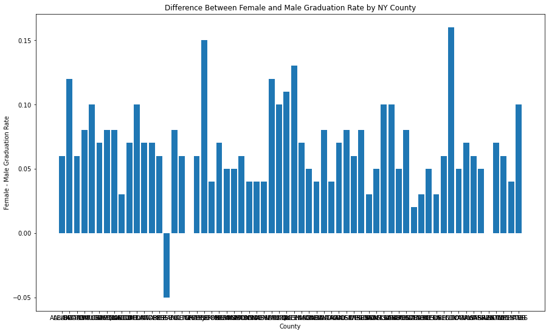

```python
sex_diff = [f - m for f,m in zip(female, male)]
plt.figure(figsize=(15, 9))
plt.bar(counties, sex_diff)

# Labeling!
plt.title("Difference Between Female and Male Graduation Rate by NY County")
plt.xlabel("County")
plt.ylabel("Female - Male Graduation Rate")
```

Let's see if there are differences between sex for our N/RC dataset. This might give us an idea about how economic factors affect gender gaps. This time, with only 7 categories, we should be okay to go back to our grouped bar chart.

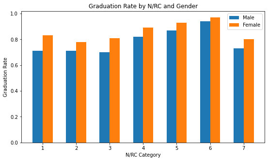

```python
# Extract our x and y values
nrc_cats = grad_nrc.category.unique() # our labels will be the NRC groups!
male_nrc = []
female_nrc = []

# Create list of male/female graduation statistics by going through each county and collecting the graduation rate
for cat in nrc_cats:
    male_nrc.append(list(grad_nrc[(grad_nrc['category'] == cat) & (grad_nrc['subgroup_name'] == 'Male')]['grad_pct'])[0])
    female_nrc.append(list(grad_nrc[(grad_nrc['category'] == cat) & (grad_nrc['subgroup_name'] == 'Female')]['grad_pct'])[0])

# Align the two side-by-side bar graphs
x = np.arange(len(nrc_cats))
width = 0.3
fig, ax = plt.subplots()
fig = plt.gcf()
fig.set_size_inches(9, 5) # make the plot bigger!
rects1 = ax.bar(x - width/2, male_nrc, width, label='Male')
rects2 = ax.bar(x + width/2, female_nrc, width, label='Female')

# Labeling!
ax.set_ylabel('Graduation Rate')
ax.set_xlabel('N/RC Category')
ax.set_title('Graduation Rate by N/RC and Gender')
ax.set_xticks(x)
ax.set_xticklabels(nrc_cats)
ax.legend()

plt.show()
```

Lots of interesting things here! First, ignoring sex, we can see that a higher N/RC corresponds to a lower overall graduation rate. The urban/suburban high N/RC groups (1, 2, 3) all hang at or below 80%, along with charter schools (7). Interestingly, rural high N/RC districts (4) do a bit better, and then graduation rates get better as we move into lower N/RC districts (5 and 6). This makes intuitive sense: districts that have a lower poverty level and a higher wealth ratio are better able to support students, and vice versa (more wealthy constituents fund the schools).

When we consider sex, another interesting trend appears: the gap between male and female graduation lessens as graduation rates overall increase (and as N/RC decreases). We go from gaps over 10% in New York City to gaps under 5% in low N/RC districts. This supports the hypothesis that as overall conditions improve in education, gaps between demographic groups close.

Next, let's take a look at overall racial differences.

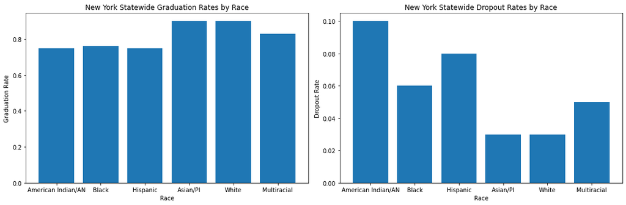

```python
# Plot differences between the six racial designations provided by NYSED

plt.figure(figsize=(15,5)) # some plot setup - size, subplot puts grad/dropout plots next to each other
plt.subplot(1, 2, 1)
x = ['American Indian/AN', 'Black', 'Hispanic', 'Asian/PI', 'White', 'Multiracial']
y = grad_state['grad_pct'][3:9] # y values from state data
plt.bar(x, y) # plot

# Always label your graphs!
plt.title("New York Statewide Graduation Rates by Race")
plt.xlabel("Race")
plt.ylabel("Graduation Rate")

# Plot dropout rates for race
plt.subplot(1, 2, 2) # next graph to plot on
y = grad_state['dropout_pct'][3:9]
plt.bar(x, y)

# Label!
plt.title("New York Statewide Dropout Rates by Race")
plt.xlabel("Race")
plt.ylabel("Dropout Rate")
plt.tight_layout()
```

Out of the "distinct" racial groups, Asian and White students sit at a very high rate of 90%. American Indian/Alaskan Native, Black, and Hispanic students are all similar and are all relatively much lower, at about 75%. In dropout rates, we see an extremely high percentage among American Indians - 10% of all students in the state for this cohort dropped out, followed by Hispanic students at 8% and Black students at 6%.

Let's see how it our N/RC data breaks down for racial differences as well. This time, we'll leave out Charter schools, because they don't clearly fit within the N/RC rating system.

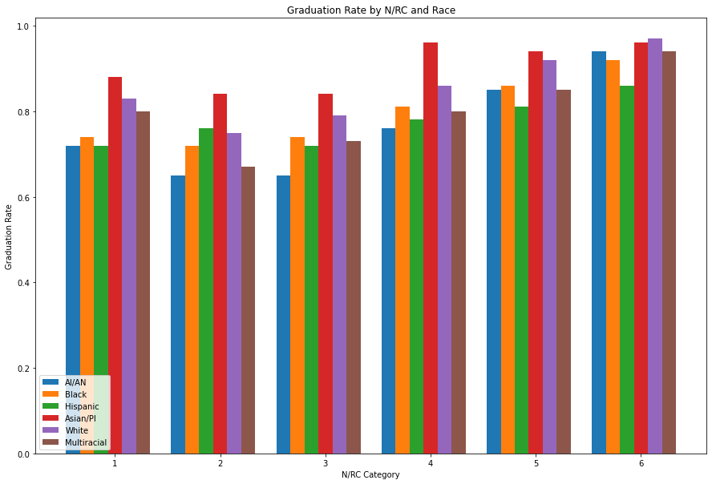

```python
# Extract our x and y values
nrc_cats = (grad_nrc.category.unique())[:6] # our labels will be the NRC groups! (minus charter schools)
ai_nrc = [] # American Indian/Alaskan Native
b_nrc = [] # Black
h_nrc = [] # Hispanic
a_nrc = [] # Asian/Pacific Islander
w_nrc = [] # White
mr_nrc = [] # Multiracial


# Create list of male/female graduation statistics by going through each county and collecting the grad rate
for cat in nrc_cats:
    ai_nrc.append(list(grad_nrc[(grad_nrc['category'] == cat) & \
                                (grad_nrc['subgroup_name'] == 'American Indian/Alaska Native')]['grad_pct'])[0])
    b_nrc.append(list(grad_nrc[(grad_nrc['category'] == cat) & \
                               (grad_nrc['subgroup_name'] == 'Black')]['grad_pct'])[0])
    h_nrc.append(list(grad_nrc[(grad_nrc['category'] == cat) & \
                               (grad_nrc['subgroup_name'] == 'Hispanic')]['grad_pct'])[0])
    a_nrc.append(list(grad_nrc[(grad_nrc['category'] == cat) & \
                               (grad_nrc['subgroup_name'] == 'Asian/Pacific Islander')]['grad_pct'])[0])
    w_nrc.append(list(grad_nrc[(grad_nrc['category'] == cat) & \
                               (grad_nrc['subgroup_name'] == 'White')]['grad_pct'])[0])
    mr_nrc.append(list(grad_nrc[(grad_nrc['category'] == cat) & \
                                (grad_nrc['subgroup_name'] == 'Multiracial')]['grad_pct'])[0])

# Align the two side-by-side bar graphs
x = np.arange(len(nrc_cats))
width = 0.8
fig, ax = plt.subplots()
fig = plt.gcf()
fig.set_size_inches(15, 10) # make the plot bigger!
rects1 = ax.bar(x - 3*width/6, ai_nrc, width/6, label='AI/AN')
rects2 = ax.bar(x - 2*width/6, b_nrc, width/6, label='Black')
rects3 = ax.bar(x - width/6, h_nrc, width/6, label='Hispanic')
rects4 = ax.bar(x, a_nrc, width/6, label='Asian/PI')
rects5 = ax.bar(x + width/6, w_nrc, width/6, label='White')
rects6 = ax.bar(x + 2*width/6, mr_nrc, width/6, label='Multiracial')


# Labeling!
ax.set_ylabel('Graduation Rate')
ax.set_xlabel('N/RC Category')
ax.set_title('Graduation Rate by N/RC and Race')
ax.set_xticks(x)
ax.set_xticklabels(nrc_cats)
ax.legend(loc=3)

plt.show()
```

## Data Analysis and Machine Learning

Running data analysis can tell us whether or not certain variables really are significant in determining our dependent variable - in this case, graduation rate. I want to see if we can predict graduation rate for a particular school district (selecting district because it's not too small like school but has a decent number of data points - aruond 700).

We only have categorical variables from our dataset: sex, race, N/RC categorization - this makes analysis rather difficult. Usually, having some continuous variables with multiple possible values gives us the best kind of models. Having only categorical variables limits the amount of predictions that we can make because we have a limited set of prediction values. Still, we'll do our best!

Let's start with an least squares linear regression (yes, this is [machine learning](https://www.sas.com/en_us/insights/analytics/machine-learning.html), too!), which attempts to minimize the square of residuals between observed and predicted values. This is a form of supervised machine learning, where we have a dataset and already know dependent variable outputs, but we want to create a model that might be able to predict values. Read more about the OLS regression [here](https://www.xlstat.com/en/solutions/features/ordinary-least-squares-regression-ols). Another option for this category of learning is a [decision tree](https://scikit-learn.org/stable/modules/tree.html), where you have a flow chart to arrive at a certain class label for data, but since we want our model to guess a continuous sliding variable with many possible outcomes, we'll stick with linear regression for now!

Because we can't just feed categorical values into the model-maker (even if those categories are hiding in the form of numbers, like our N/RC categories are), we need to turn them into dummy columns of 1s and 0s. That way, our model will be able to take their values (present or not) and make decisions based on that. Note that we also need to drop one of the dummy columns per variable, because its absence or presence can be derived from the other category values.

We'll also split the data that we have into a training set and a testing set, with a ratio of 80-20. When we make models, it's a good idea to have two sets because we don't want to overfit a model by making it so attuned to a set of data that it doesn't generalize at all to other sets. Later on, we can make sure the model achieves similar results between our training and testing sets.

The independent variables that I want to use are sex, race, and N/RC category, because based on the exploration we did before, it appears that they have some bearing on graduation rates. From a linear regression, we can see how much individual variables affect graduation rate and if they're significant.

```python
# Perform an Ordinary Least Squares (OLS) Linear Regression on N/RC data

# Create a revised dataset with some dummy columns:

# Extract only the rows with subgroups we care about (sex and race)
grad_dist_ols = grad_district[(grad_district['subgroup_code'] == 2) | (grad_district['subgroup_code'] == 3)| \
                              (grad_district['subgroup_code'] == 4) | (grad_district['subgroup_code'] == 5) | \
                              (grad_district['subgroup_code'] == 6) | (grad_district['subgroup_code'] == 7) |\
                              (grad_district['subgroup_code'] == 8) |(grad_district['subgroup_code'] == 9)]

# Get dummy columns from categorical variable N/RC code
nrc = pd.get_dummies(grad_dist_ols.nrc_code, drop_first=True, prefix = 'nrc')
# Get dummy columns from other demographic variables - sex and race
subgroup = pd.get_dummies(grad_dist_ols.subgroup_name, prefix = 'sub')
# Drop one from each category; female for sex and AI/AN for race
subgroup = subgroup.drop(labels=['sub_Male', 'sub_American Indian/Alaska Native'], axis = 1)
other = grad_dist_ols[['grad_pct']] # extract other x and y cols
combined = pd.concat([nrc, subgroup, other], axis = 1) # combine columns

# Split the dataset into training and testing so we can check if our model is overfitted later
training = combined.sample(frac = 0.8, random_state = 50) # random state is a seed for reproducibility
testing = combined.drop(training.index)

# Run the regression on our new dataset with dummy variables:

X = training.drop(labels=['grad_pct'], axis = 1) # get indepedent variable columns
X = sm.add_constant(X) # add a constant column of 1s (needed for statsmodels regression)
Y = training['grad_pct'] # get y values of graduation percentage

model = sm.OLS(Y,X).fit() # fit the model to a line
model.summary() # print a summary of the fit
```

OLS Regression Results

| Dep. Variable: | grad_pct | R-squared: | 0.350 |
| --- | --- | --- | --- |
| Model: | OLS | Adj. R-squared: | 0.347 |
| Method: | Least Squares | F-statistic: | 107.0 |
| Date: | Sun, 16 May 2021 | Prob (F-statistic): | 3.06e-195 |
| Time: | 00:43:57 | Log-Likelihood: | 1948.7 |
| No. Observations: | 2194 | AIC: | -3873. |
| Df Residuals: | 2182 | BIC: | -3805. |
| Df Model: | 11 |  |  |
| Covariance Type: | nonrobust |  |  |

|  | coef | std err | t | P>\|t\| | [0.025 | 0.975] |
| --- | --- | --- | --- | --- | --- | --- |
| const | 0.7155 | 0.008 | 86.480 | 0.000 | 0.699 | 0.732 |
| nrc_2.0 | 0.0005 | 0.021 | 0.025 | 0.980 | -0.040 | 0.041 |
| nrc_3.0 | 0.0300 | 0.010 | 2.919 | 0.004 | 0.010 | 0.050 |
| nrc_4.0 | 0.1070 | 0.009 | 11.568 | 0.000 | 0.089 | 0.125 |
| nrc_5.0 | 0.1490 | 0.008 | 18.707 | 0.000 | 0.133 | 0.165 |
| nrc_6.0 | 0.2008 | 0.009 | 23.083 | 0.000 | 0.184 | 0.218 |
| sub_Asian/Pacific Islander | 0.0845 | 0.009 | 9.286 | 0.000 | 0.067 | 0.102 |
| sub_Black | -7.97e-05 | 0.008 | -0.009 | 0.992 | -0.017 | 0.017 |
| sub_Female | 0.0650 | 0.006 | 10.676 | 0.000 | 0.053 | 0.077 |
| sub_Hispanic | -0.0372 | 0.008 | -4.881 | 0.000 | -0.052 | -0.022 |
| sub_Multiracial | 0.0003 | 0.011 | 0.023 | 0.982 | -0.022 | 0.023 |
| sub_White | 0.0385 | 0.006 | 5.970 | 0.000 | 0.026 | 0.051 |

| Omnibus: | 1398.267 | Durbin-Watson: | 1.998 |
| --- | --- | --- | --- |
| Prob(Omnibus): | 0.000 | Jarque-Bera (JB): | 30307.084 |
| Skew: | -2.635 | Prob(JB): | 0.00 |
| Kurtosis: | 20.429 | Cond. No. | 12.5 |

Notes:  
[1] Standard Errors assume that the covariance matrix of the errors is correctly specified.

Now we have this nice summary output where statsmodels has already run the linear regression and some significance testing on the coefficients for us. You can read more about the in depth analysis of what this summary provides [here](https://medium.com/swlh/interpreting-linear-regression-through-statsmodels-summary-4796d359035a), but for now let's focus on the r-squared value and the coefficients and significance of each of the variables.

Each coefficient tells us how much the predicted value changes when our population has a certain attribute. For example, we can see that being Asian/Pacific Islander boosts graduation rate predictions by around 8% compared to the "baseline" of American Indian/Alaskan Native. These values make sense when we remember the distributions over race seen in our exploratory phase. Being female apparently gives around 6% of a boost over being male, and being in a low N/RC district grants the biggest boost of all the variables, an increase of 20% over being in New York City.

Read more in depth about hypothesis testing and what we can use it for [here](https://www.statisticshowto.com/probability-and-statistics/hypothesis-testing/).

```python
# Check r2 score of running our model on the 20% test data

testX = testing.drop(labels=['grad_pct'], axis = 1) # get X values from testing set
testX = sm.add_constant(testX) # add constant
predtest = model.predict(testX) # get predicted values of testing set
print(r2_score(testing['grad_pct'], predtest)) # print r2 value of testing set predictions
```

```
0.3293184518673904
```

Good! When I first ran this code with whatever random testing sample df.sample() gave me, I got an r-squared value of approximately 0.329. Running this code multiple times (splitting the dataset and running the model) should give similar values each time. Because our r-squared for the training sample matches our testing sample (in the 0.3s), we can rest assured that we haven't overfit the model.

Let's think about another linear regression issue: residuals. Generating a linear model relies on certain assumptions about the data that may or may not have been met. If unmet, it calls into question the reliability of the linear model. In particular, we should find that when mapped against our independent values, our residuals are randomly scattered with no pattern. This is called [homoscedasticity](https://www.statisticssolutions.com/homoscedasticity/). If we have extreme heteroscedasticity, it can cause issues with standard error and the values that we use to do significance testing, but it would have to be quite pronounced to present a problem. We have a lot of independent values - let's take a look at how the residuals are.

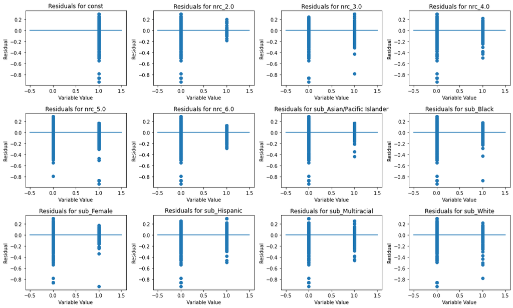

```python
predictions = model.predict(X) # get predictions for the training set
resid = Y - predictions # get residuals for the training set (actual - expected)

# for each independent variable, graph independent variable values against the residuals
plt.figure(figsize=(15, 9)) # make the plot larger

for i, varb in enumerate(X.columns):
    plt.subplot(3, 4, i + 1)
    plt.tight_layout()
    plt.scatter(X[varb], resid)
    plt.plot([-0.5,1.5], [0,0])

    plt.title("Residuals for " + varb)
    plt.xlabel("Variable Value")
    plt.ylabel("Residual")
```

For these residuals we would hope to see that the points are evenly spread between positive and negative. Obviously each category is only going to have points split between 0 and 1, since those are its only values, but if the residuals don't appear to cluster above or below the 0.0 line, we should be okay. Many of the graphs come out decently. Unfortunately, there does appear to be a bit of a skew to lower residuals for some of the variables, like White and Female and N/RC 5. Overall, negative residuals are lower, revealing the left skew in the starting data. This is rather unavoidable - because we're calculating graduation rate, there's a hard cap at 1. Most of the points are around 0.8, and the bulk of the data is very close to the ceiling (which is great for us as a society but not so great for getting an even distribution).

## Conclusion

From this analysis we have learned that race, gender, and need-to-resource capacity category definitely affect a district's graduation rates. We've seen from our exploration that as resources increase, gaps between demographic groups might become smaller. Although these factors alone don't explain everything about graduation rates, I suspect that if we had more related continuous data - things like the actual N/RC ratios, district incomes, number of teachers and support staff - we would be able to generate even more powerful predictive models. That's a possible further avenue: aggregating some other district-level datasets from New York that can fill in some of those missing gaps.

There are many models and datasets out there - you can explore any number of them and see if you can find interesting outcomes. Even this New York dataset, while very limited, still has more avenues of exploration because of its sheer size and inclusion of divisons - for example, we could also run the regression using county divisions and see how big of a factor county is on graduation rates (my guess is that this would be another piece of the model puzzle!).

I believe that education has a unique role in shaping the trajectory of individuals and communities, and it's our society's job to make sure we're providing the best education possible to as many students as possible. Data science and research into which groups are in most need to additional resources can inform policy decisions to continue pushing the upward trend of graduation rates!

Like all good things, we must reach the end! I hope you've learned something from this tutorial and had fun reading through some of my analysis. Check out some of the sources linked throughout the tutorial for more in depth exploration of many of the topics I touched on.